# HW4.5_arturoAltamirano

The true target is f(x) = x^2, where x is a random uniform real value in [-1,1], and the observed target is y=f(x)+s =x^2+s where s is an independent Gaussian random noise of mean 0 and standard deviation=sigma.

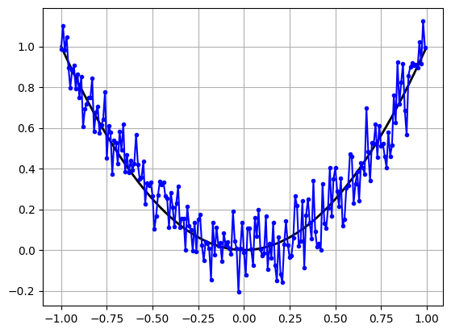

```python
import random
import numpy as np
import matplotlib.pyplot as plt

#if you want a seed, i developed this notebook without one. 42 looks to be good.
random.seed(42)

np.set_printoptions(precision = 5, suppress=True)

#x_line = np.linspace(-1, 1, 200)
#x_line = np.random.uniform(-1,1)
x_line = np.arange(-1., 1., .01)

#y-values in coordination with true f(x) = x^2, where x is a random uniform real value in [-1,1]
y_line = x_line**2

#independent Gaussian random noise
#of mean 0
mu = 0
#and standard deviation = sigma (0.1)
sigma = 0.1
#cast perturbation across length N (x_line)
N = len(x_line)
#dimensions
d=2

#observed target is y=f(x)+s =x^2+s where s is an independent Gaussian random noise
y_observed = y_line + np.random.normal(mu, sigma, size=N)

#re-use my data capture tactic from HW3
fig, ax = plt.subplots()
lineObject = []
noiseData = []

#true function data
line, = ax.plot(x_line, y_line, linewidth=2, color='black')
lineObject.append(line)

x_data = line.get_xdata()
y_data = line.get_ydata()

noise, = ax.plot(x_line, y_observed, 'b.')
noise, = ax.plot(x_line,y_observed, color='blue')

ax.grid(True)
plt.show()
```

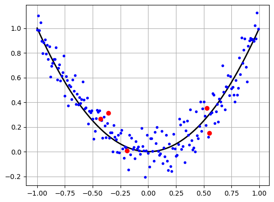

```python
#First randomly sample N=5 points D={(xi,yi)}
num_samples = 5
random_indices = np.random.choice(N, num_samples, replace=False)

sampled_x = x_line[random_indices]
sampled_y = y_observed[random_indices]

fig, ax = plt.subplots()
ax.plot(x_line, y_line, linewidth=2, color='black')
ax.plot(x_line, y_observed, 'b.')
ax.scatter(sampled_x, sampled_y, color='red', zorder=5)

#D = datapoints (x values)
D = list(sampled_x)
#y = labels (y values)
y = list(sampled_y)

ax.grid(True)
plt.show()
```

We will try to fit the data D using the nonlinear transform technique. Create 4-dimensional (plus constant 1) data by mapping each x in D to z=[1,z1,z2,z3,z4]^T where z1(x)= x, z2(x)=1/2*(3*x^2 - 1), z3(x)=1/2*(5*x^3-3*x), z4(x)=1/8*( 35*x^4-30*x^2+3). These are the Legendre polynomials from p.10 of Lecture 12.

```python
D = np.array(D)

print(f'data (x-values) in D:{D}\n')

#legendre transformation as provided by assignment
def Phi(x):
    return [1, x, 1./2*(3*x**2 - 1), 1./2*(5*x**3 - 3*x), 1./8*(35*x**4 - 30*x**2 + 3)]

legendre_polynomials = []

#for every x (uniform real value) pass and acquire transformations on that point
for point in list(D):
    transformations = Phi(point)
    transformations = np.round(transformations,3)
    print(f'data point: {point.round(3)}')
    print(f'Phi transformations of point: {transformations}\n')
    legendre_polynomials.append(transformations)

#for each x value in D sampled data, returns list of arrays containing the legendre transforms of each x passed
print(legendre_polynomials)
```

```
data (x-values) in D:[-0.43 -0.36  0.53  0.55 -0.19]

data point: -0.43
Phi transformations of point: [ 1.    -0.43  -0.223  0.446 -0.169]

data point: -0.36
Phi transformations of point: [ 1.    -0.36  -0.306  0.423 -0.038]

data point: 0.53
Phi transformations of point: [ 1.     0.53  -0.079 -0.423 -0.333]

data point: 0.55
Phi transformations of point: [ 1.     0.55  -0.046 -0.409 -0.359]

data point: -0.19
Phi transformations of point: [ 1.    -0.19  -0.446  0.268  0.245]

[array([ 1.   , -0.43 , -0.223,  0.446, -0.169]), array([ 1.   , -0.36 , -0.306,  0.423, -0.038]), array([ 1.   ,  0.53 , -0.079, -0.423, -0.333]), array([ 1.   ,  0.55 , -0.046, -0.409, -0.359]), array([ 1.   , -0.19 , -0.446,  0.268,  0.245])]
```

Our hypothesis is therefore h(z) = w^Tz = w0 + w1*z1 + w2*z2 + w3*z3 + w4*z4. Stack the transformed data into the matrix Z.

```python
#still doing linear regression
#N x features
#large z matrix with size samples, arranged horizontally with transforms
Z = np.array(legendre_polynomials)

print(f'original data (D):\n {D}\n')

print(f'transformed data (Z):\n {Z}\n')

#print(f'{Z.transpose()}\n')
```

```
original data (D):
 [-0.43 -0.36  0.53  0.55 -0.19]

transformed data (Z):
 [[ 1.    -0.43  -0.223  0.446 -0.169]
 [ 1.    -0.36  -0.306  0.423 -0.038]
 [ 1.     0.53  -0.079 -0.423 -0.333]
 [ 1.     0.55  -0.046 -0.409 -0.359]
 [ 1.    -0.19  -0.446  0.268  0.245]]
```

We minimize the sum of the l2 error 1/N*||Zw-y||^2 and the regularization term lambda/N*w^Tw. The CLOSED-FORM solution exists and is given by w = (Z^T Z + lambda*I)^{-1} Z^T y as explained in class. (I is the identity matrix np.eye()) Let's consider four values of lambda: L=[0, 1E-5, 1E-2, 1E0].

```python
#sample lambda (you multiply this by the identity matrix and add to matrix transpose)
lam = 1E-2

#non-regularized version from prior homework
old_dag = np.matmul( np.linalg.pinv(np.matmul(Z.transpose(), Z)), Z.transpose())
old_dag = old_dag.round(3)
print(f'without regularization (from prior assignment):\n {old_dag}\n')
#old_w = np.matmul(old_dag, Y)

#w = (Z^T Z + lambda*I)^{-1} Z^T y
#what value to np.eye()? - pinv or inv?
Zdag = np.matmul(np.linalg.pinv(np.matmul(Z.transpose(), Z) + lam * np.eye(int(len(Z)))), Z.transpose())
Zdag = Zdag.round(3)
print(f'with regularization (Zdag): \n{Zdag}')

y = np.array(y)

#weights (y) = y values of sampled points
w_old = np.matmul(old_dag, y)
print(f'\nw_old (what it would be without regularization): \n{w_old}')

#Z^T y
w_reg = np.matmul(Zdag, y)
print(f'\nw_reg (regularized): \n{w_reg}')
#w = np.matmul(Zdag, Z)

#print(f'without regularization: {old_w}')
#print(f'with regularization: {w}')

#Z is the legendre polynomials of the 5 sampled x scalars along gaussian noise of target function
x = D[0]
h_x = np.matmul(w_reg, Phi(x))

print(f'\ninput data point: {x.round(3)} hypothesis: {h_x.round(3)}')

noise_h_x = np.matmul(w_old, Phi(x))

print(f'\ninput data point: {x.round(3)} hypothesis: {noise_h_x.round(3)}')
```

```
without regularization (from prior assignment):
 [[  8.862 -12.792  -8.281   8.249   4.961]
 [-14.7    19.098  -9.719  10.428  -5.108]
 [ 25.839 -38.113 -32.633  31.375  13.532]
 [-13.491  19.189 -13.913  13.57   -5.356]
 [ 14.224 -23.351 -17.925  16.689  10.363]]

with regularization (Zdag):
[[ 0.304 -0.041  0.082  0.307  0.282]
 [-1.187  0.543 -0.488  1.007  0.169]
 [ 0.823 -0.394 -0.638  0.767 -0.759]
 [-0.221  1.145 -1.159  0.706 -0.438]
 [-0.868 -0.559 -0.441  0.02   1.729]]

w_old (what it would be without regularization):
[ -3.2648    0.13458 -11.66756  -0.52     -7.21591]

w_reg (regularized):
[ 0.14481 -0.16784 -0.01746 -0.00681 -0.54679]

input data point: -0.43 hypothesis: 0.31

input data point: -0.43 hypothesis: 0.261
```

```python
#Err_loocv = np.zeros(4) ## because there are four values of lamda

#L=[0, 1E-5, 1E-2,  1E0].

#for i, lambda in enumerate([0, 1E-5, 1E-2,  1E0]):
    #Err_temp = np.zeros(N) # used for leave-one-out error
    #ind_train = np.setdiff1d(np.arange(N), ind_val) # all examples but ind_val
    #Ztrain = Z[ind_train,:]
    #Zval = Z[ind_val,:]
    #Now train with Ztrain and evaluate with Zval
    #Save the current validation error in Err_temp[ind_val]

#Err_loocv[i] = np.mean(Err_temp)
```

```python
Err_loocv = np.zeros(4) ## because there are four values of lamda

N = 5
lambdas = [0, 1E-5, 1E-2, 1E0]

y = np.array(y)

for i, lam in enumerate(lambdas):
    Err_temp = np.zeros(N) # used for leave-one-out error
    for ind_val in range(N): # N=5
        ind_train = np.setdiff1d(np.arange(N), ind_val) # all examples but i

        Ztrain = Z[ind_train,:]
        y_train = y[ind_train]

        #gradient dissent or matrix inverse
        #w = (Z^T Z + lambda*I)^{-1}
        Zdag = np.matmul(np.linalg.pinv(np.matmul(Ztrain.transpose(), Ztrain) + lam * np.eye(int(len(D)))), Ztrain.transpose())
        Zdag = Zdag.round(3)

        #print(f'train data (only 4 with held out validation):\n {Ztrain.round(3)}\n')
        #print(f'train output:\n {Zdag}\n')

        Zval = Z[ind_val,:]

        #w = z train transpose ...... z train y
        #make prediction for held out point
        #Ypred = W^T zval * w
        #MSE for error calculation

        #couldn't understand what y was, but then realized the points themselves are labels
        #no longer an arbitrary label like in classification, the goal here is developing the
        #function exclusively

        #Z^T y
        #why does order matter in matrix multiplication?
        w_reg_loop = np.matmul(Zdag, y_train)
        y_pred = np.dot(w_reg_loop, Zval)

        #print(f'prediction from weights: {y_pred}')

        #print(f'validation point: {y[ind_val]}')

        #MEAN. SQUARED. Error.
        mean_sq_err = (y_pred - y[ind_val]) ** 2
        Err_temp[ind_val] = mean_sq_err
        #print(f'MSE: {mean_sq_err}\n')

        #print(f'validation data (held out validation point):\n {Zval.round(3)}\n')

    Err_loocv[i] = np.mean(Err_temp)

#Err_loocv = np.round(Err_loocv,3)

for x in range(len(Err_loocv)):
    print(f'λ = {lambdas[x]}, LOOCV Error = {Err_loocv[x].round(3)}')

#super crude, but functional, way of checking what lowest lambda loocv value is 'what lambda is best?'
lambLow0 = False
lambLowE_5 = False
lambLowE_2 = False
lambLow1 = False

if min(Err_loocv) == Err_loocv[0]:
    lambLow0 = True
    print(f'\nλ = 0 is lowest loocv at {Err_loocv[0].round(3)}')

elif min(Err_loocv) == Err_loocv[1]:
    lambLowE_5 = True
    print(f'\nλ = 0.00001 is lowest loocv at {Err_loocv[1].round(3)}')

elif min(Err_loocv) == Err_loocv[2]:
    lambLowE_2 = True
    print(f'\nλ = 0.01 is lowest loocv at {Err_loocv[2].round(3)}')

elif min(Err_loocv) == Err_loocv[3]:
    lambLow1 = True
    print(f'\nλ = 1.0 is lowest loocv at {Err_loocv[3].round(3)}')
```

```
λ = 0, LOOCV Error = 0.159
λ = 1e-05, LOOCV Error = 0.157
λ = 0.01, LOOCV Error = 0.06
λ = 1.0, LOOCV Error = 0.031

λ = 1.0 is lowest loocv at 0.031
```

## Err_loocv is not a perfect measure and it does not always agree with avg squared error.

## NOTE: The below code encompasses a-2 a-3 and b-1 as it retrains with all lambda values. I included code to designate the chosen hypothesis based on LOOCV. I figured this does both with one cell.

```python
#remember from first cell:
#x_line = np.arange(-1., 1., .01)

#y-values in coordination with true f(x) = x^2, where x is a random uniform real value in [-1,1]
#y_line = x_line**2

def hypothesis_weight_generator(lambda_setting, y, Z):
    """"
    pass in a lambda setting, labels, and legendre data matrix
    """
    #w = (Z^T Z + lambda*I)^{-1} Z^T y
    #what value to np.eye()? - pinv or inv?
    Zdag = np.matmul(np.linalg.pinv(np.matmul(Z.transpose(), Z) + lambda_setting * np.eye(int(len(Z)))), Z.transpose())
    Zdag = Zdag.round(3)
    #print(f'regularized matrix (Zdag): \n{Zdag}')

    w_reg = np.matmul(Zdag, y)
    #print(f'\nregularized weights: \n{w_reg}')
    #w = np.matmul(Zdag, Z)

    return w_reg

def avg_sq_error (y_line, hypothesis_line):
    """
    average squared error to replicate out of sample error
    """
    #squared_errors = [(y_line - hypothesis_line)**2 for x in y_line]
    squared_errors = (y_line - hypothesis_line)**2

    return np.mean(squared_errors)

#generate learned weights for every specified lambda - one of these is the designated hypothesis
zero_weights = hypothesis_weight_generator(0,y,Z)
Ezero_weights = hypothesis_weight_generator(1E0,y,Z)
Eminus2_weights = hypothesis_weight_generator(1E-2,y,Z)
Eminus5_weights = hypothesis_weight_generator(1E-5,y,Z)

#across span of x_line (-1,1 arange) pass this point to Phi legendre function
#then evalaute high-dimensional data against learned weights according to lambda regularization
zero_hypothesis = [np.matmul(zero_weights, Phi(x)) for x in x_line]
Ezero_hypothesis = [np.matmul(Ezero_weights, Phi(x)) for x in x_line]
Eminus2_hypothesis = [np.matmul(Eminus2_weights, Phi(x)) for x in x_line]
Eminus5_hypothesis = [np.matmul(Eminus5_weights, Phi(x)) for x in x_line]

#pass true labels (true y cordinate data) and the generated hypothesis to calculate mean sq err
zero_mean_err = avg_sq_error(y_line, zero_hypothesis)
Ezero_mean_err = avg_sq_error(y_line, Ezero_hypothesis)
Eminus2_mean_err = avg_sq_error(y_line, Eminus2_hypothesis)
Eminus5_mean_err = avg_sq_error(y_line, Eminus5_hypothesis)
```

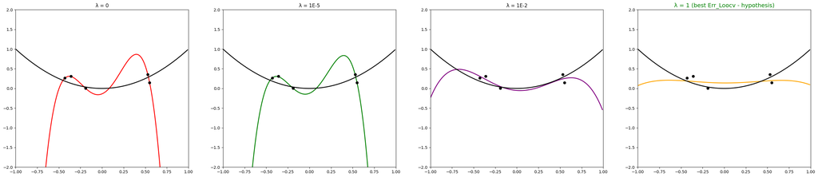

```python
fig, (ax1,ax2,ax3,ax4) = plt.subplots(1,4)

fig.set_figheight(7)
fig.set_figwidth(35)

#probably a fancier way of doing this iteratively but manually specifying each subplot works
ax1.plot(x_line, zero_hypothesis, linewidth=2, color='red')

#randomly sampled noise points
ax1.scatter(sampled_x, sampled_y,label='sampled point',color='black',zorder=5)

#target function
ax1.plot(x_line, y_line, linewidth=2, label='target',color='black')

ax1.title.set_text('λ = 0')

ax1.set_xlim(-1,1)
ax1.set_ylim(-2,2)

ax2.plot(x_line, Eminus5_hypothesis, linewidth=2, color='green')

#randomly sampled noise points
ax2.scatter(sampled_x, sampled_y,label='sampled point',color='black',zorder=5)

#target function
ax2.plot(x_line, y_line, linewidth=2, label='target',color='black')

ax2.title.set_text('λ = 1E-5')

ax2.set_xlim(-1,1)
ax2.set_ylim(-2,2)

ax3.plot(x_line, Eminus2_hypothesis,linewidth=2, color='purple')

#randomly sampled noise points
ax3.scatter(sampled_x, sampled_y,label='sampled point',color='black',zorder=5)

#target function
ax3.plot(x_line, y_line, linewidth=2, label='target',color='black')

ax3.title.set_text('λ = 1E-2')

ax3.set_xlim(-1,1)
ax3.set_ylim(-2,2)

ax4.plot(x_line, Ezero_hypothesis, linewidth=2, color='orange')

#randomly sampled noise points
ax4.scatter(sampled_x, sampled_y,label='sampled point',color='black',zorder=5)

#target function
ax4.plot(x_line, y_line, linewidth=2, label='target',color='black')

ax4.title.set_text('λ = 1')

ax4.set_xlim(-1,1)
ax4.set_ylim(-2,2)

#silly code to designate best Err_Loocv
if lambLow0:
    ax1.set_title('λ = 0 (best Err_Loocv - hypothesis)', color='green', fontsize=14)

elif lambLowE_5:
    ax2.set_title('λ = 1E-5 (best Err-Loocv - hypothesis)', color='green', fontsize=14)

elif lambLowE_2:
    ax3.set_title('λ = 1E-2 (best Err-Loocv - hypothesis)', color='green', fontsize=14)

elif lambLow1:
    ax4.set_title('λ = 1 (best Err_Loocv - hypothesis)', color='green', fontsize=14)
```

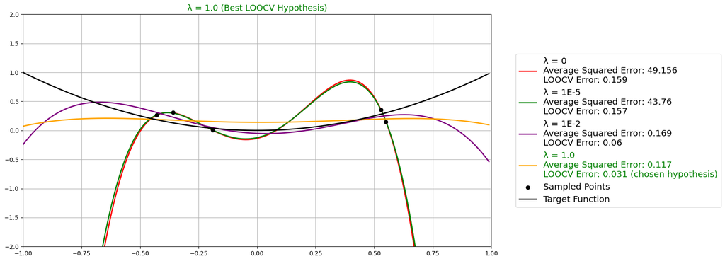

```python
fig, ax = plt.subplots()

x_line = np.arange(-1., 1., .01)

#capture best lambda for title
best_lambda_label = None
if lambLow0:
    best_lambda_label = "λ = 0"
elif lambLowE_5:
    best_lambda_label = "λ = 1E-5"
elif lambLowE_2:
    best_lambda_label = "λ = 1E-2"
elif lambLow1:
    best_lambda_label = "λ = 1.0"

fig.set_figheight(7)
fig.set_figwidth(14)

plt.xlim(-1, 1)
plt.ylim(-2, 2)

#plot all the lines with metrics
ax.plot(x_line, zero_hypothesis, linewidth=2, color='red',
        label=f'λ = 0\nAverage Squared Error: {zero_mean_err.round(3)}\n'
        f'LOOCV Error: {Err_loocv[0].round(3)}')

ax.plot(x_line, Eminus5_hypothesis, linewidth=2, color='green',
        label=f'λ = 1E-5 \nAverage Squared Error: {Eminus5_mean_err.round(3)}\n'
        f'LOOCV Error: {Err_loocv[1].round(3)}')

ax.plot(x_line, Eminus2_hypothesis, linewidth=2, color='purple',
        label=f'λ = 1E-2 \nAverage Squared Error: {Eminus2_mean_err.round(3)}\n'
        f'LOOCV Error: {Err_loocv[2].round(3)}')

ax.plot(x_line, Ezero_hypothesis, linewidth=2, color='orange',
        label=f'λ = 1.0\nAverage Squared Error: {Ezero_mean_err.round(3)}\n'
        f'LOOCV Error: {Err_loocv[-1].round(3)}')

#dynamic set title to show chosen hypothesis
if best_lambda_label:
    ax.set_title(f"{best_lambda_label} (Best LOOCV Hypothesis)", fontsize=14, color="green")

ax.scatter(sampled_x, sampled_y, label='Sampled Points', color='black', zorder=5)

ax.plot(x_line, y_line, linewidth=2, label='Target Function', color='black')

ax.grid(True)

legend = plt.legend(loc='right', fontsize='x-large', bbox_to_anchor=(1.5, 0.5))

#highlight chosen hypothesis with some dynamic code - couldn't figure out
#how to do it with hard-code like above
#decided to use .get_texts() and variable defined above
#https://github.com/matplotlib/matplotlib/blob/v3.10.1/lib/matplotlib/legend.py#L994-L996
for text in legend.get_texts():
    if best_lambda_label in text.get_text():
        text.set_color("green")
        text.set_fontsize("x-large")

        new_text = text.get_text() + " (chosen hypothesis)"
        text.set_text(new_text)

plt.show()
```

## Best lambda value is generally 1E-2 for this given target function. lambda = 1 will also yield a better result at a good rate.

## It seems that more often than not, LOOCV is a good indicator of the best hypothesis, but somtimes can be slightly off.

## On different runs, the sampled points may fall in a configuration which makes one or the other better.

## 0 (unregularized) is obviously the worst, and 1E-5 doesn't put a tight enough leash on the hypothesis.

## Re-run the notebook to see different points!